# Personal Regression Application

## Background

My inspiration for this project was my family. We enjoy playing board games together and, as with any family playing a game, it can get pretty competitive. In this analysis, I would like to optimize my game play for Ticket to Ride (the original) by knowing how to get the most points through the least amount of time and effort.

For anyone not familiar with the game, your goal is to connect cities by trains and you get points for laying down trains (an important note at this point would be to say that some of these tracks require certain colors but some are gray and you can use any color to play them and others have double tracks so that two players may connect these cities). The big points come through destination tickets which give you additional points for having connected certain cities together. I have seen that the points that make or break a game are the ones gained through these destination tickets on top of the points from the actual trains you lay down. Because of this, I will only be including information for these destination tickets in this level of the analysis.

To start, it was necessary that I collected all the data from the board. The variables that I thought would be of use were points from the tickets, tracks between the two cities, how many of those are colored, and how many of those tracks are double tracks as all these are part of the strategy.

Data was collected from finding the shortest path from one city to another as this will be the prime track (and assumes that no one will take any of the track before you are able to get there). The remaining variables chosen were then determined from that information.

## Finding the Right Model

I first started with the pairs plot below

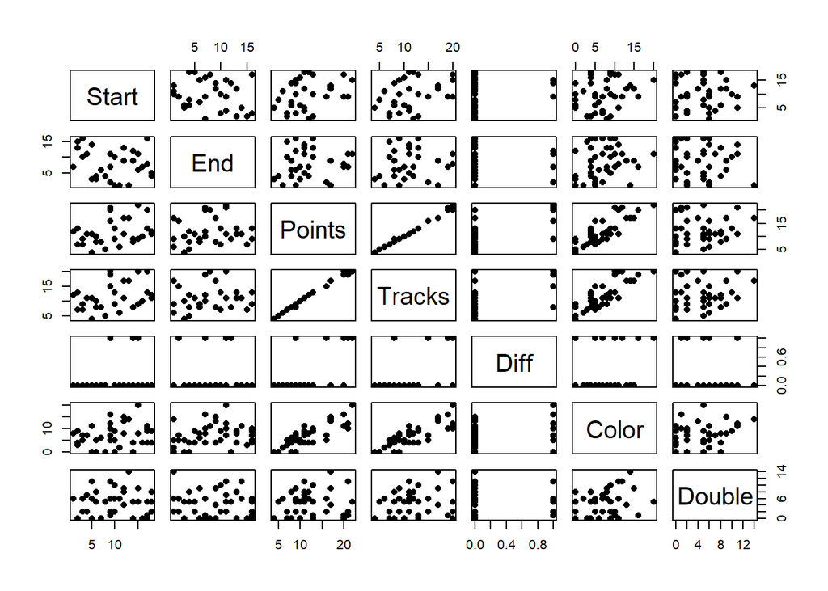

```r
pairs(ticket, pch = 16)
```

The one that jumps out very quickly was points vs tracks between the cities. There also looks to be a possible relationship with the binary response of whether the points to track is different or the same. Below, I colored the variables by this additional variable as well.

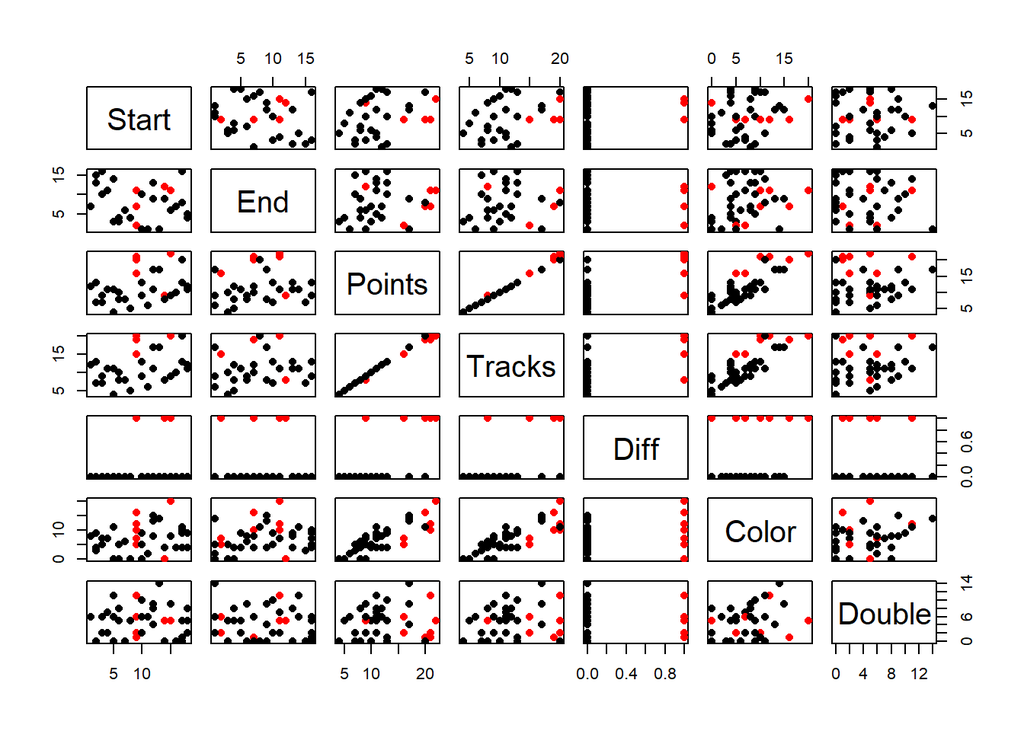

```r
pairs(ticket, pch = 16, col = as.factor(ticket$Diff))
```

```r
ticket.lm <- lm(Points ~ Tracks + Diff, data = ticket)
```

Because there looks to be a relationship between `Points`, `Tracks`, and `Difference`, I constructed just a linear model with those included. I then created a pairs plot including the Residuals vs variables to see if there were any patterns.

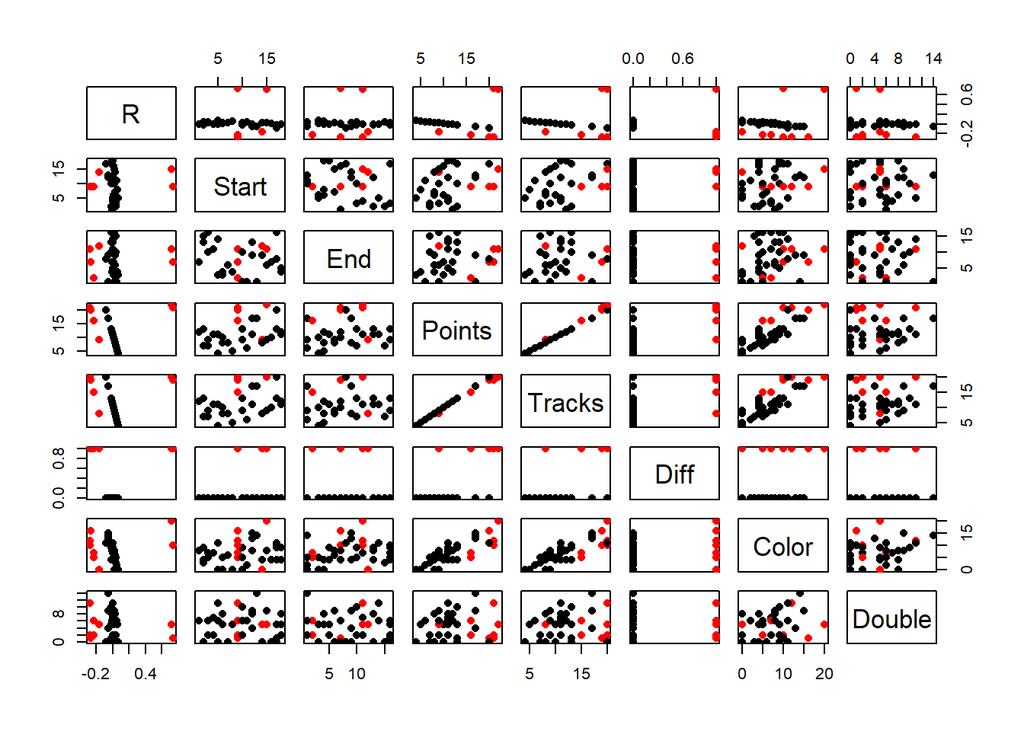

```r
pairs(cbind(R = ticket.lm$residual, ticket), pch = 16, col = as.factor(ticket$Diff))
```

One pattern that does seem to jump out is adding the colors of the tracks into the model as well so that is something to possibly include.

## Analysis of Models

Lets first start with comparing the full and reduced model of including color. Below are also my hypotheses and below that is the $F$ test:

$$H_0: \beta_3 = 0 \\
H_a: \beta_3 \neq 0$$

```r
ticket.lm.red <- lm(Points ~ Tracks + Diff + Color, data = ticket)
anova(ticket.lm,ticket.lm.red)
```

```
Analysis of Variance Table

Model 1: Points ~ Tracks + Diff
Model 2: Points ~ Tracks + Diff + Color
  Res.Df    RSS Df Sum of Sq      F Pr(>F)
1     39 1.4527
2     38 1.3641  1  0.088649 2.4695 0.1244
```

As can be seen, the addition of the `Color` variable does not make a difference in our model and will therefore not be included. As a note, I found similar findings for the adition of the `Double` variable. Below is the summary of our model as it stands along with a scatter plot showing these relationships.

```r
summary(ticket.lm)
```

```
Call:
lm(formula = Points ~ Tracks + Diff, data = ticket)

Residuals:
     Min       1Q   Median       3Q      Max
-0.27836 -0.02057 -0.00167  0.01724  0.73109

Coefficients:
             Estimate Std. Error t value Pr(>|t|)
(Intercept) -0.102313   0.096672  -1.058    0.296
Tracks       1.009453   0.008392 120.290  < 2e-16 ***
Diff         1.191615   0.091860  12.972 9.99e-16 ***
---
Signif. codes:  0 '***' 0.001 '**' 0.01 '*' 0.05 '.' 0.1 ' ' 1

Residual standard error: 0.193 on 39 degrees of freedom
Multiple R-squared:  0.9984,    Adjusted R-squared:  0.9983
F-statistic: 1.203e+04 on 2 and 39 DF,  p-value: < 2.2e-16
```

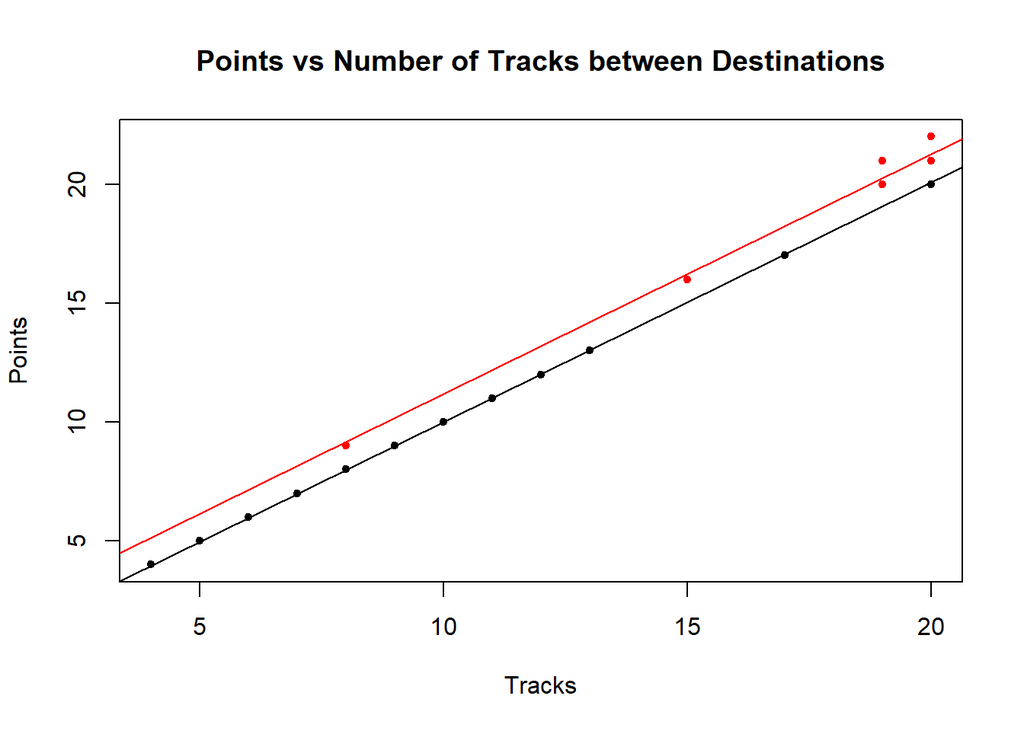

```r
plot(Points ~ Tracks, col = as.factor(Diff), data = ticket, pch = 20, main = "Points vs Number of Tracks between Destinations")
b <- coef(ticket.lm)
abline(b[1], b[2])
abline(b[1] + b[3], b[2], col = "red")
```

My next question is the interaction of these variables. Is it useful to change the slope $and$ the intercept. Below is the $F$ test as well as the plot that would be produced as well as our equation.

$$\hat{Y_i} = 8.771*10^{-15} + 1 X_{i1} + 0.5645 X_{i2} + 0.04032 X_{i1} X_{i2}$$

```r
ticket.lm.red2 <- lm(Points ~ Tracks + Diff + Tracks:Diff, data = ticket)
anova(ticket.lm,ticket.lm.red2)
```

```
Analysis of Variance Table

Model 1: Points ~ Tracks + Diff
Model 2: Points ~ Tracks + Diff + Tracks:Diff
  Res.Df    RSS Df Sum of Sq      F  Pr(>F)
1     39 1.4527
2     38 1.2984  1   0.15435 4.5173 0.04011 *
---
Signif. codes:  0 '***' 0.001 '**' 0.01 '*' 0.05 '.' 0.1 ' ' 1
```

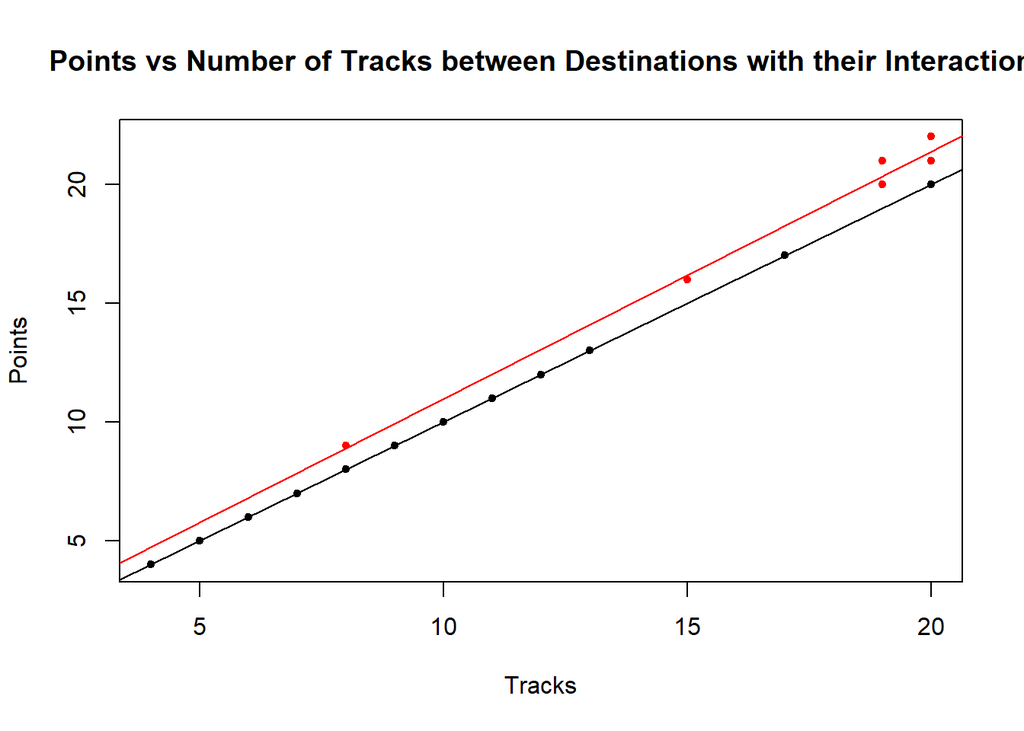

```r
plot(Points ~ Tracks, col = as.factor(Diff), data = ticket, pch = 20, main = "Points vs Number of Tracks between Destinations with their Interaction")
c <- coef(ticket.lm.red2)
abline(c[1],c[2])
abline(c[1] + c[3], c[2] + c[4], col = "red")
```

Based on the analysis, it is barely significant to include the interaction between the two and could possibly come from the lack of datapoints at that point. There are some worries with the diagnostic plots which I will show below.

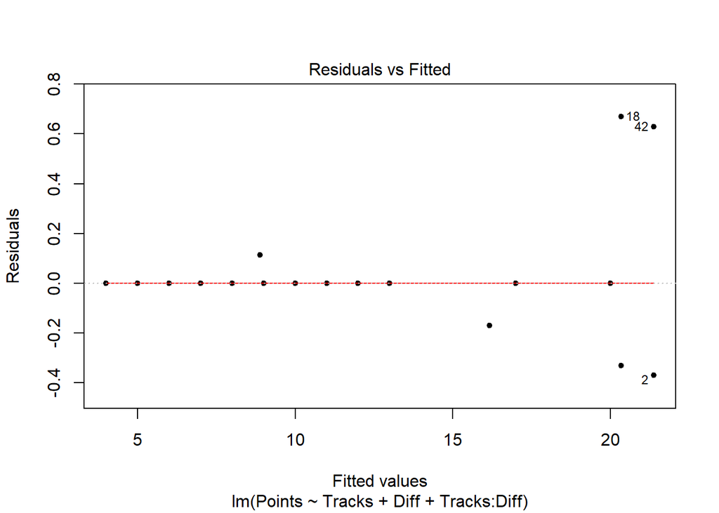

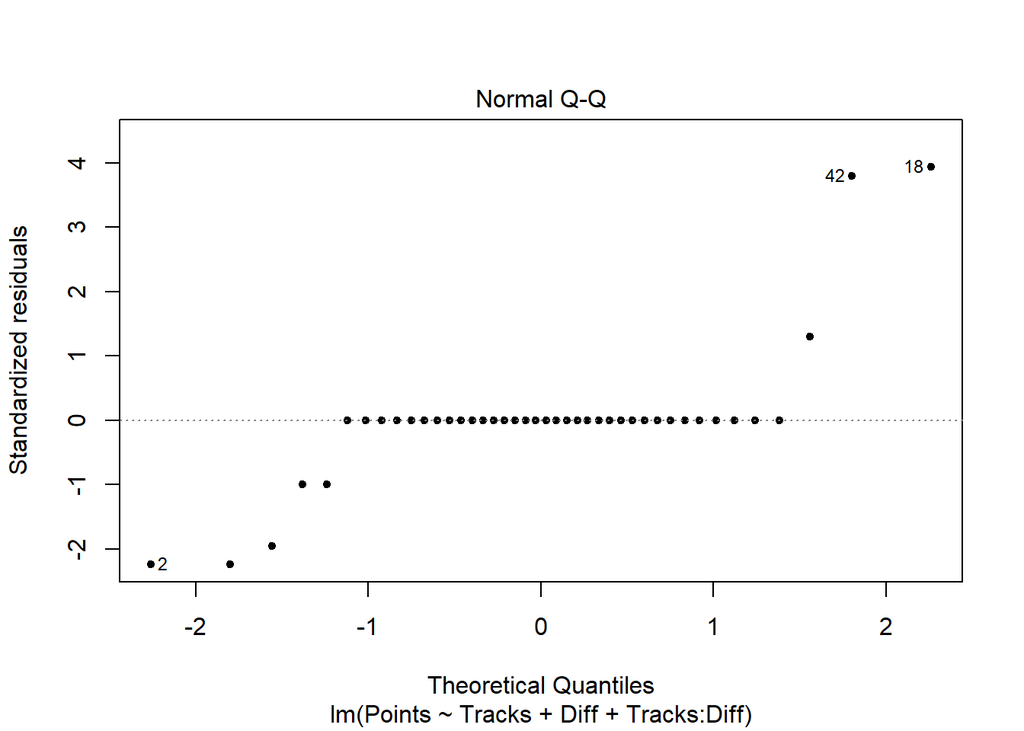

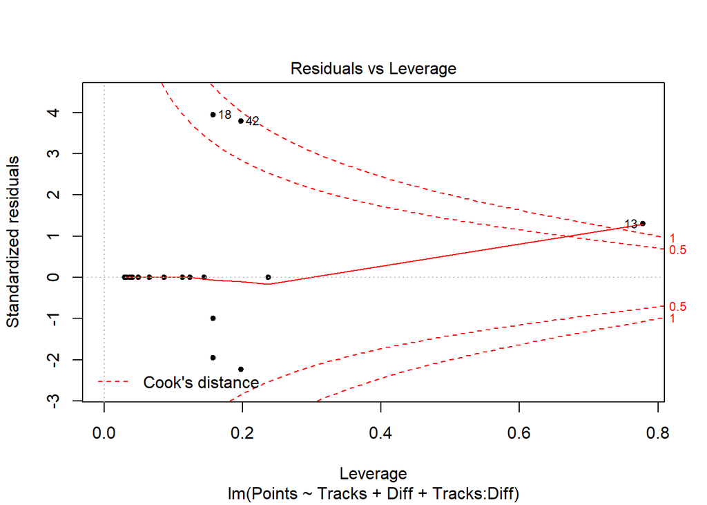

```r
plot(ticket.lm.red2, which = c(1:2,5), pch = 20)
```

With variance, there is a definite megaphone shape, the normality of the residual distributions is concerning and then it looks like there are a few points that are outliers that may throw everything off quite a bit. For this project, I will keep it in our model.

## Exploration of Other Models

I would like to compare two other models outside of the regular linear model. This is a robust regression and a poisson regression. My rationale for robust is the outliers seen in the last section, and poisson because there are only so many cards that a player can choose, as well as part of the game being that you don’t want too many cards as they can hurt your score.

#### Robust Regression

With the robust regression, we will add weights to our variables. That plot can be seen below.

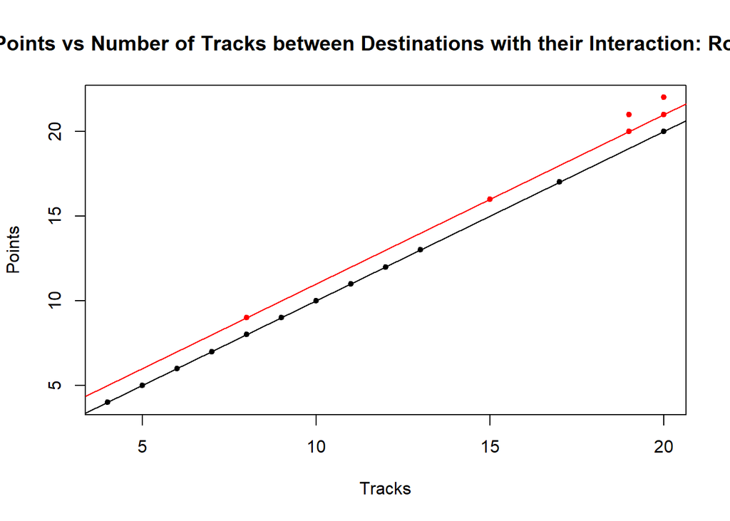

```r
ticket.rlm <- rlm(Points ~ Tracks + Diff + Tracks:Diff, data = ticket)
d <- coef(ticket.rlm)
plot(Points ~ Tracks, col = as.factor(Diff), data = ticket, pch = 20, main = "Points vs Number of Tracks between Destinations with their Interaction: Robust")
abline(d[1], d[2])
abline(d[1] + d[3], d[2] + d[4], col = "red")
```

This looks very similar to our original model. I will plot both in the same plot.

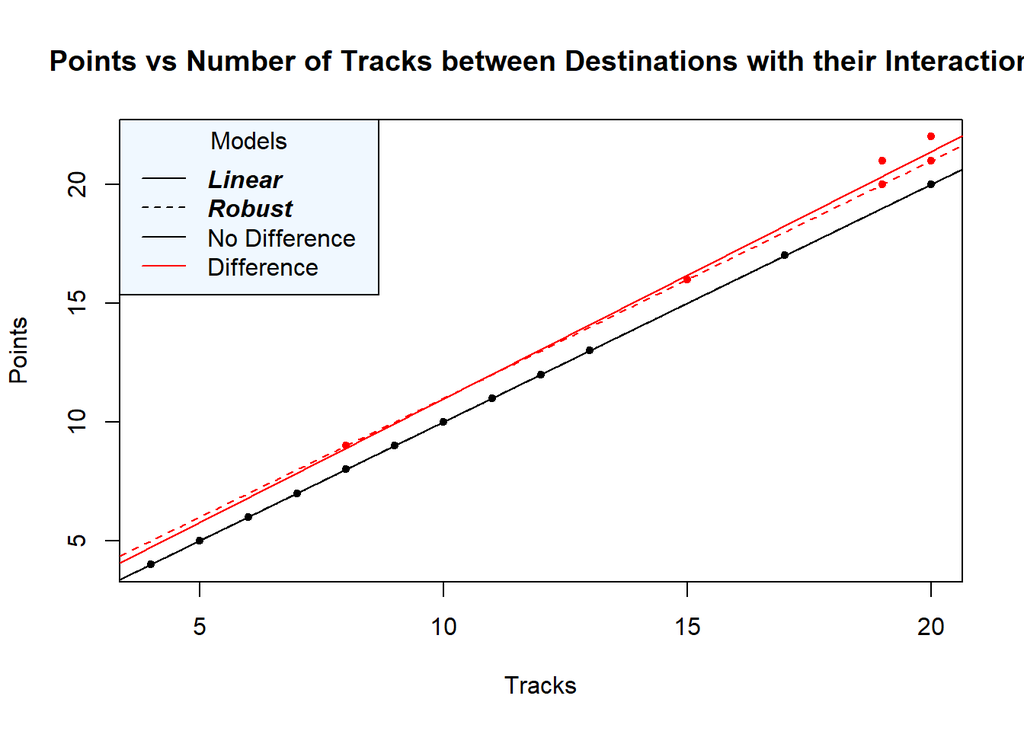

```r
plot(Points ~ Tracks, col = as.factor(Diff), data = ticket, pch = 20, main = "Points vs Number of Tracks between Destinations with their Interaction")
abline(c[1], c[2])
abline(c[1] + c[3], c[2] + c[4], col = "red")
abline(d[1], d[2], lty = 2)
abline(d[1] + d[3], d[2] + d[4], col = "red", lty = 2)
legend("topleft", legend = c("Linear", "Robust", "No Difference", "Difference"), col = c("Black", "Black", "Black", "Red"), lty = c(1:2,1,1), title = "Models", text.font = c(4,4,1,1), bg = "aliceblue")
```

#### Poisson Regression

With the poisson regression, our model changes to as follows.

$$\mu(X, \beta) = e^{\beta_0 + \beta_1 X_{i1} + \beta_2 X_{i2} + \beta_3 X_{i1} X_{i2}}$$

The plot for this model is as follows:

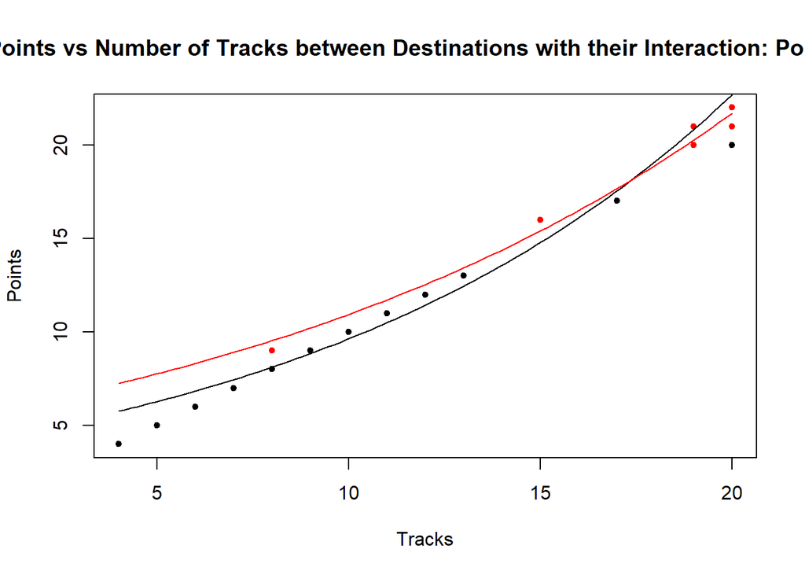

```r
ticket.pois <- glm(Points ~ Tracks + Diff + Tracks:Diff, data = ticket, family = poisson)
e <- coef(ticket.pois)
plot(Points ~ Tracks, col = as.factor(Diff), data = ticket, pch = 20, main = "Points vs Number of Tracks between Destinations with their Interaction: Poisson")
curve(exp(e[1] + e[2] * x), add = TRUE)
curve(exp((e[1] + e[3]) + (e[2] + e[4]) * x), add = TRUE, col = "red")
```

I am not so certain that this would be a better fit. If we looked at the summary below:

```r
summary(ticket.pois)
```

```
Call:
glm(formula = Points ~ Tracks + Diff + Tracks:Diff, family = poisson,
    data = ticket)

Deviance Residuals:
     Min        1Q    Median        3Q       Max
-0.77658  -0.13181   0.05802   0.15290   0.16619

Coefficients:
            Estimate Std. Error z value Pr(>|z|)
(Intercept)  1.40823    0.17533   8.032 9.58e-16 ***
Tracks       0.08569    0.01404   6.104 1.03e-09 ***
Diff         0.29807    0.49665   0.600    0.548
Tracks:Diff -0.01713    0.02917  -0.587    0.557
---
Signif. codes:  0 '***' 0.001 '**' 0.01 '*' 0.05 '.' 0.1 ' ' 1

(Dispersion parameter for poisson family taken to be 1)

    Null deviance: 72.0982  on 41  degrees of freedom
Residual deviance:  1.9953  on 38  degrees of freedom
AIC: 189.96

Number of Fisher Scoring iterations: 3
```

```r
ticket.pois.red <- glm(Points ~ Tracks, data = ticket, family = poisson)
anova(ticket.pois,ticket.pois.red)
```

```
Analysis of Deviance Table

Model 1: Points ~ Tracks + Diff + Tracks:Diff
Model 2: Points ~ Tracks
  Resid. Df Resid. Dev Df Deviance
1        38     1.9953
2        40     2.3456 -2 -0.35023
```

There does not seem to be a significant difference between the two so we will continue with our original analysis.

Below, as before, I have created a plot comparing our linear model to this poisson model.

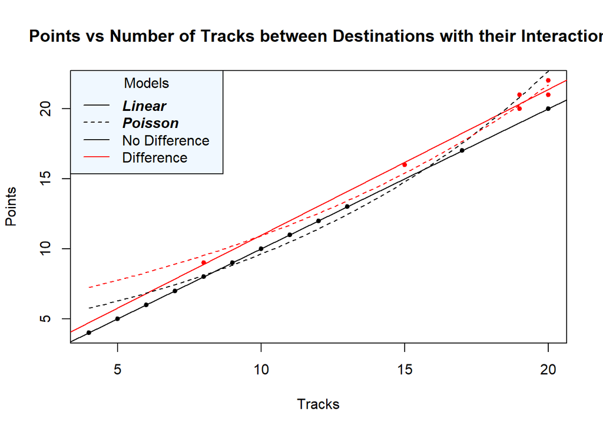

```r
plot(Points ~ Tracks, col = as.factor(Diff), data = ticket, pch = 20, main = "Points vs Number of Tracks between Destinations with their Interaction")
abline(c[1], c[2])
abline(c[1] + c[3], c[2] + c[4], col = "red")
curve(exp(e[1] + e[2] * x), add = TRUE, lty = 2)
curve(exp((e[1] + e[3]) + (e[2] + e[4]) * x), add = TRUE, col = "red", lty = 2)
legend("topleft", legend = c("Linear", "Poisson", "No Difference", "Difference"), col = c("Black", "Black", "Black", "Red"), lty = c(1:2,1,1), title = "Models", text.font = c(4,4,1,1), bg = "aliceblue")
```

## Conclusion and Interpretation

For my final conclusion, I would say that the original linear regression, without any worry of weights, is the most appropriate model for our task.

As a player of Ticket to Ride, it looks like I would want to get destination cards where there is a difference between the point value and the tracks connecting them. Ideally this would be one of the cards with a larger point value in order to win. This would mean I would want to hold on to any of the following cards.

```r
pander(subset(ticket, Diff == "1", select = -5))
```

|  | Start | End | Points | Tracks | Color | Double |
| --- | --- | --- | --- | --- | --- | --- |
| **1** | Los Angeles | New York | 21 | 20 | 10 | 2 |
| **2** | Los Angeles | New York | 21 | 20 | 12 | 11 |
| **13** | Saul Ste Marie | Oklahoma City | 9 | 8 | 0 | 5 |
| **17** | Los Angeles | Miami | 20 | 19 | 16 | 1 |
| **18** | Los Angeles | Miami | 21 | 19 | 10 | 1 |
| **26** | Los Angeles | Chicago | 16 | 15 | 7 | 6 |
| **27** | Los Angeles | Chicago | 16 | 15 | 5 | 2 |
| **42** | Seattle | New York | 22 | 20 | 20 | 5 |